# Topic Change Analysis

Joaquim Neto

```r
    require(ggplot2)
    setwd("~/PyCharm-Workspace/tribunaldb/")
    load('ts_data.RData')
```

# Objetivos:

### 1) Descobrir possíveis pontos de virada, aonde o *ofensor* passa de um comportamento normal para um comportamento tóxico

### 2) Descobrir os principais tópicos para cada *timeslice*

### 3) Descobrir quais as principais tendências de troca de tópico

(ie. topico a tende a mudar para topico b)

# Parâmetros

#### Tamanho de cada timeslice:

600s

#### Clusterizador e dados usados:

LDA, sem divisão de grupos por timeslice, dataset NA completo.

#### Peso usado na interpretação

tf(cluster)-idf(corpus) aplicado nas top-100 palavras de cada cluster.

# Preprocessamento

#### 1) Removido timeslices acima de 60min(engloba ~95% das tslices)

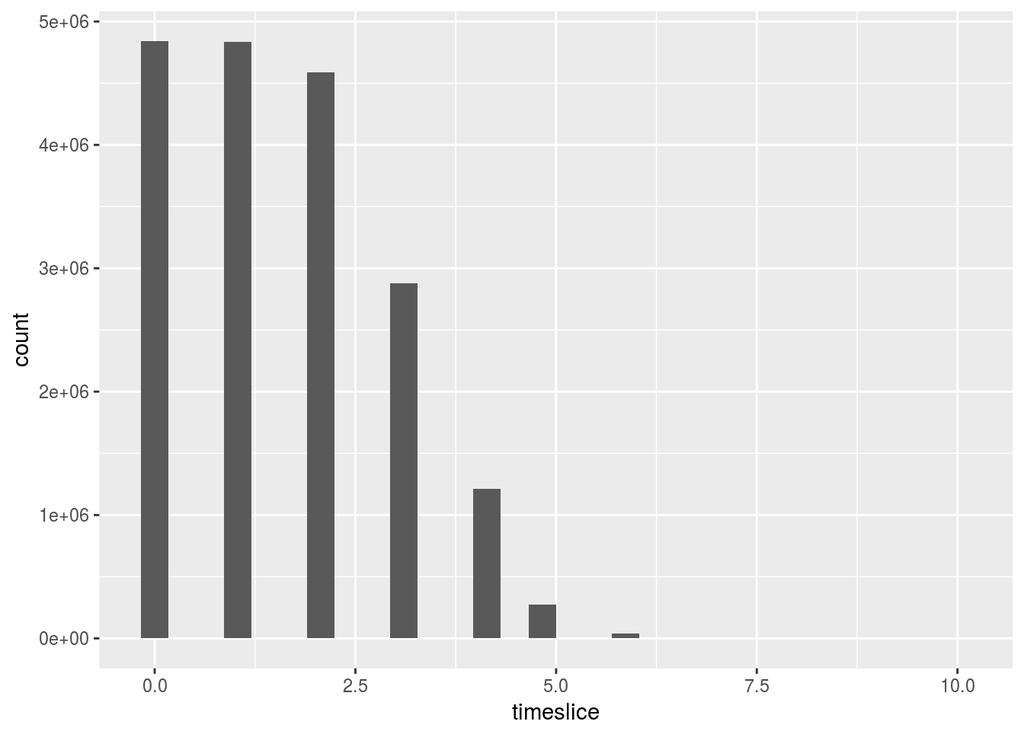

# Análise

## Uso dos tópicos através dos timeslices

### Método:

#### Todos os grupos

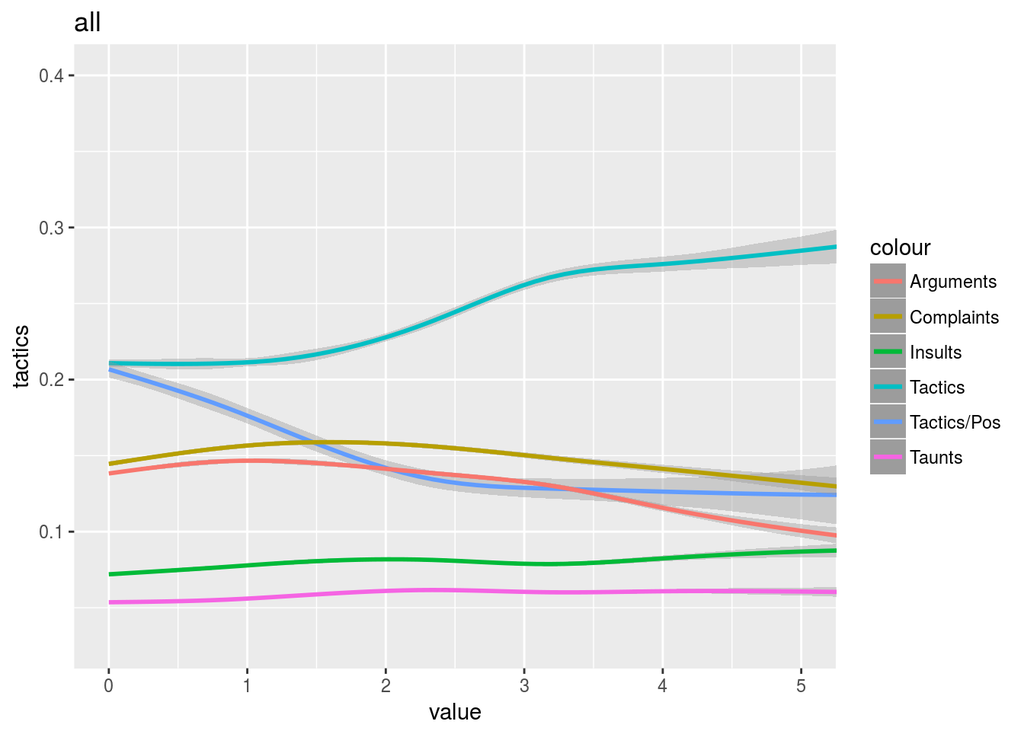

#### Grupos inimigos

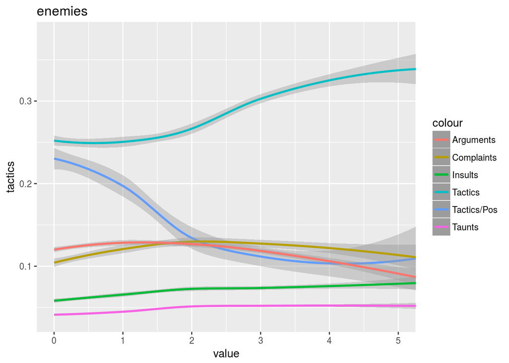

#### Grupos aliados

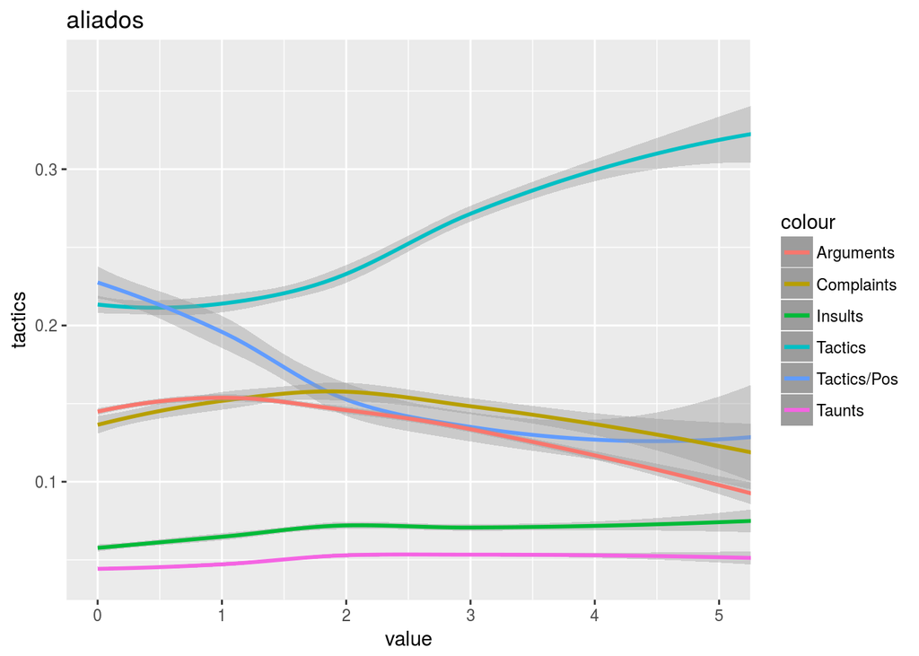

#### Grupos ofensores

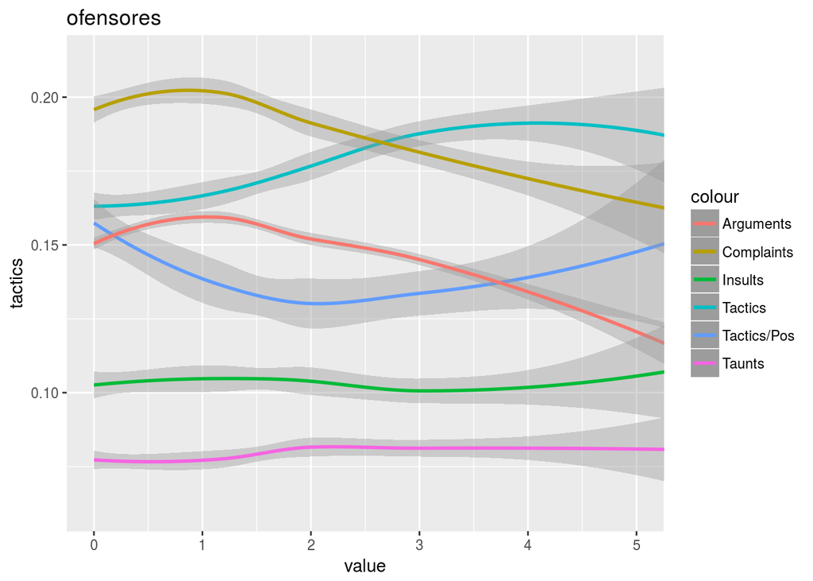

### Divisão em pos/neg

#### Todos os Grupos:

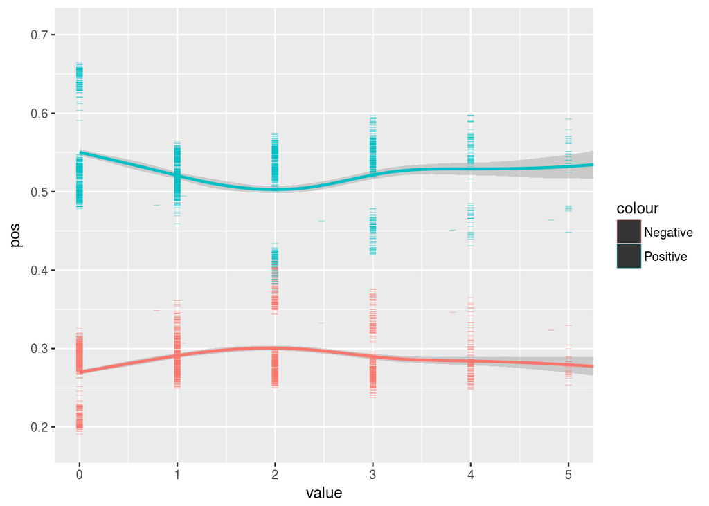

#### Grupos Aliados:

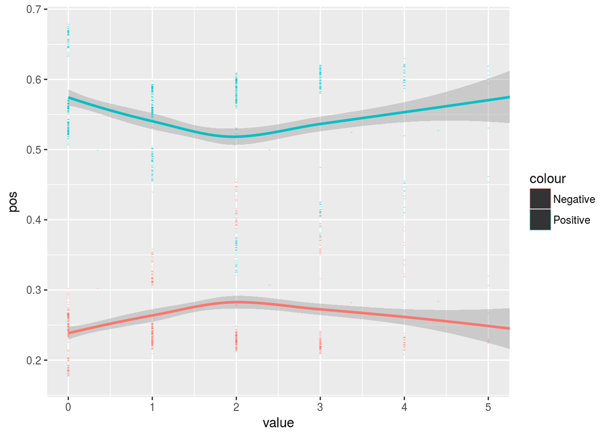

#### Grupos Inimigos:

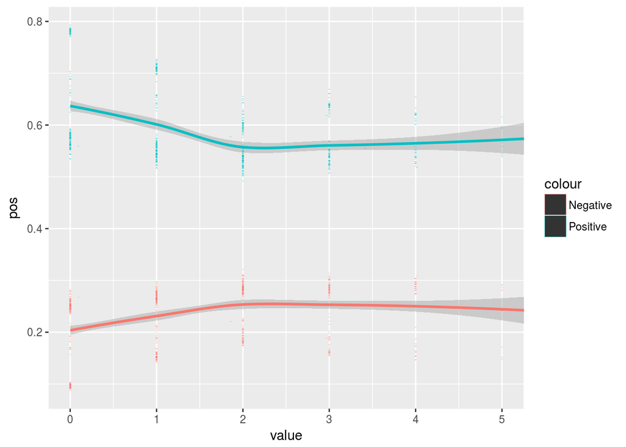

#### Grupos Ofensores:

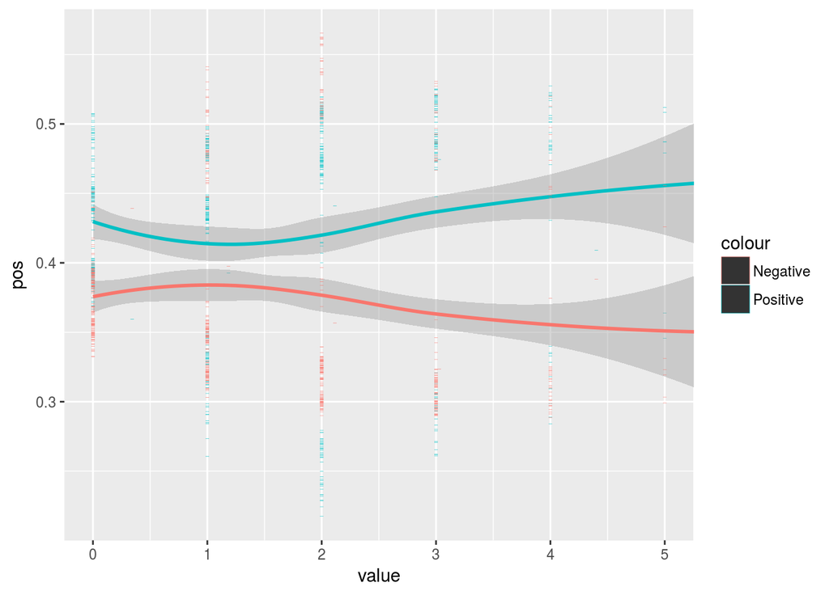

## Relação entre tópicos em diferentes timeslices

### Experimento 0:

Apriori com 50% de confiança e 33% de suporte, limitado as timeslices 0 e 1, intervalo no qual os gráficos apresentam alguma variação

#### ts.0=Tactics

{ts.1=tactics} => {ts.0=tactics} com 40% de suporte

#### ts.0=Tactics.Pos,

Nenhum resultado relevante.

#### ts.0=small.talk

Nenhum resultado relevante.

#### ts.0=complaints

Nenhum resultado relevante.

#### ts.0=arguments

Nenhum resultado relevante.

#### ts.0=insults

Nenhum resultado relevante.

#### ts.0=taunts

Nenhum resultado relevante.

#### Conclusões

Não parecem existir relações significantes

### Experimento 1:

Apriori com 50% de confiança e 33% de suporte, limitado as timeslices 1 e 2, intervalo no qual os gráficos apresentam alguma variação

#### ts.1=Tactics

ts2.tactics -> ts.1.tactics com 38% de suporte e 100% de confiança.

#### ts.1=Tactics.Pos,

Nenhum resultado relevante.

#### ts.1=small.talk

Nenhum resultado relevante.

#### ts.1=complaints

Nenhum resultado relevante.

#### ts.1=arguments

Nenhum resultado relevante.

#### ts.1=insults

Nenhum resultado relevante.

#### ts.1=taunts

Nenhum resultado relevante.

#### Conclusões

Não parecem existir relações significantes

### Experimento 2:

Apriori com 50% de confiança e 33% de suporte, limitado as timeslices 2 e 3, intervalo no qual os gráficos apresentam alguma variação

#### ts.2=Tactics

Nenhum resultado relevante.

#### ts.2=Tactics.Pos,

{ts.3=empty} => {ts.2=tactics.pos}, com 44% de suporte

#### ts.2=small.talk

{ts.3=empty} => {ts.2=small.talk} com 40% de suporte

#### ts.2=complaints

{ts.3=empty} => {ts.2=complaints} com 42% de suporte

#### ts.2=arguments

{ts.3=empty} => {ts.2=arguments} com 38% de suporte

#### ts.2=insults

{ts.3=empty} => {ts.2=insults} com 43% de suporte

#### ts.2=taunts

{ts.3=empty} => {ts.2=taunts} com 43% de suporte

#### Conclusões

Esses resultados não parecem significar muita coisa além de uma quantidade maior de ‘empty’(sem conversas) em ts.3 do que em ts.2, o que de fato acontece(43% vs 14%).

### Experimento 3:

Apriori com 33% de confiança e 5% de suporte, usando todas as timeslices, e todos os tópicos. Suporte é baixo devido aos desbalanceamentos entre os grupos.

#### Conclusões

Sem resultados conclusivos, de 300+ regras, a maioria esmagadora dizia de algum modo que empty -> empty e topic -> topic